# Week 1 - Homework

STAT 420, Summer 2021, D. Unger

## Exercise 1 (Subsetting and Statistics)

For this exercise, we will use the `msleep` dataset from the `ggplot2` package.

**(a)** Install and load the `ggplot2` package. **Do not** include the installation command in your `.Rmd` file. (If you do it will install the package every time you knit your file.) **Do** include the command to load the package into your environment.

```r
library('ggplot2')
```

**(b)** Note that this dataset is technically a `tibble`, not a data frame. How many observations are in this dataset? How many variables? What are the observations in this dataset? Number of Observations: 83 Number of Variables: 11 Observations:

```r
msl <- ggplot2::msleep
msl
```

```
## # A tibble: 83 x 11
##    name   genus vore  order conservation sleep_total sleep_rem sleep_cycle awake
##    <chr>  <chr> <chr> <chr> <chr>              <dbl>     <dbl>       <dbl> <dbl>
##  1 Cheet~ Acin~ carni Carn~ lc                  12.1      NA        NA      11.9
##  2 Owl m~ Aotus omni  Prim~ <NA>                17         1.8      NA       7
##  3 Mount~ Aplo~ herbi Rode~ nt                  14.4       2.4      NA       9.6
##  4 Great~ Blar~ omni  Sori~ lc                  14.9       2.3       0.133   9.1
##  5 Cow    Bos   herbi Arti~ domesticated         4         0.7       0.667  20
##  6 Three~ Brad~ herbi Pilo~ <NA>                14.4       2.2       0.767   9.6
##  7 North~ Call~ carni Carn~ vu                   8.7       1.4       0.383  15.3
##  8 Vespe~ Calo~ <NA>  Rode~ <NA>                 7        NA        NA      17
##  9 Dog    Canis carni Carn~ domesticated        10.1       2.9       0.333  13.9
## 10 Roe d~ Capr~ herbi Arti~ lc                   3        NA        NA      21
## # ... with 73 more rows, and 2 more variables: brainwt <dbl>, bodywt <dbl>
```

**(c)** What is the mean hours of REM sleep of individuals in this dataset?

```r
mean(msl$sleep_rem, na.rm=TRUE)
```

```
## [1] 1.87541
```

**(d)** What is the standard deviation of brain weight of individuals in this dataset?

```r
sd(msl$brainwt, na.rm=TRUE)
```

```
## [1] 0.9764137
```

**(e)** Which observation (provide the `name`) in this dataset gets the most REM sleep?

```r
msl[which.max(msl$sleep_rem), ]$name
```

```
## [1] "Thick-tailed opposum"
```

```r
mean(msl$bodywt, na.rm = TRUE)
```

```
## [1] 166.1363
```

## Exercise 2 (Plotting)

For this exercise, we will use the `birthwt` dataset from the `MASS` package.

**(a)** Note that this dataset is a data frame and all of the variables are numeric. How many observations are in this dataset? How many variables? What are the observations in this dataset?

```r
library("MASS")
bw <- MASS::birthwt
bw
```

```
##     low age lwt race smoke ptl ht ui ftv  bwt
## 85    0  19 182    2     0   0  0  1   0 2523
## 86    0  33 155    3     0   0  0  0   3 2551
## 87    0  20 105    1     1   0  0  0   1 2557
## 88    0  21 108    1     1   0  0  1   2 2594
## 89    0  18 107    1     1   0  0  1   0 2600
## 91    0  21 124    3     0   0  0  0   0 2622
## 92    0  22 118    1     0   0  0  0   1 2637
## 93    0  17 103    3     0   0  0  0   1 2637
## 94    0  29 123    1     1   0  0  0   1 2663
## 95    0  26 113    1     1   0  0  0   0 2665
## 96    0  19  95    3     0   0  0  0   0 2722
## 97    0  19 150    3     0   0  0  0   1 2733
## 98    0  22  95    3     0   0  1  0   0 2751
## 99    0  30 107    3     0   1  0  1   2 2750
```

[output cut: 175 more lines]

Number of Observations: 189 Number of variables: 10 Observations shown above.

**(b)** Create a scatter plot of birth weight (y-axis) vs mother’s weight before pregnancy (x-axis). Use a non-default color for the points. (Also, be sure to give the plot a title and label the axes appropriately.) Based on the scatter plot, does there seem to be a relationship between the two variables? Briefly explain.

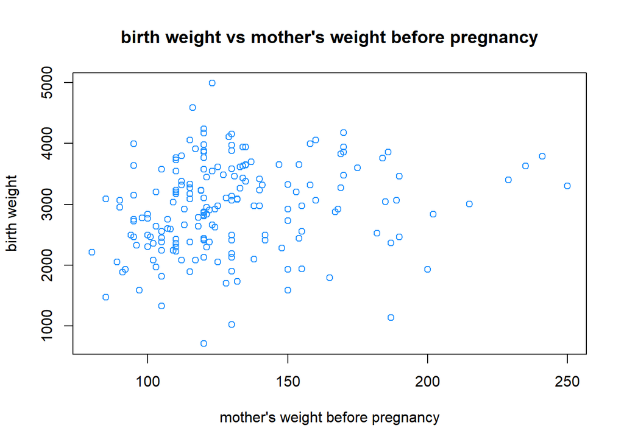

```r
plot(bwt ~ lwt, data = bw,
     col = "dodgerblue",
     xlab = "mother's weight before pregnancy",
     ylab = "birth weight",
     main = "birth weight vs mother's weight before pregnancy")
```

No relationship between two variables since the dots in the plot looks randomly spreaded as mother’s weight increase.

**(c)** Create a scatter plot of birth weight (y-axis) vs mother’s age (x-axis). Use a non-default color for the points. (Also, be sure to give the plot a title and label the axes appropriately.) Based on the scatter plot, does there seem to be a relationship between the two variables? Briefly explain.

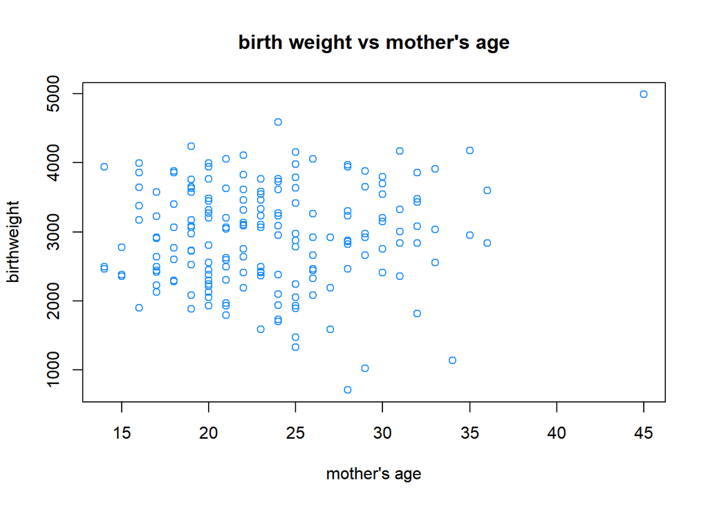

```r
plot(bwt ~ age, data = bw,
     col = "dodgerblue",
     xlab = "mother's age",
     ylab = "birthweight",
     main = "birth weight vs mother's age")
```

No relation between the two variables. Dots are evenly distributed as mother’s age increase.

**(d)** Create side-by-side boxplots for birth weight grouped by smoking status. Use non-default colors for the plot. (Also, be sure to give the plot a title and label the axes appropriately.) Based on the boxplot, does there seem to be a difference in birth weight for mothers who smoked? Briefly explain.

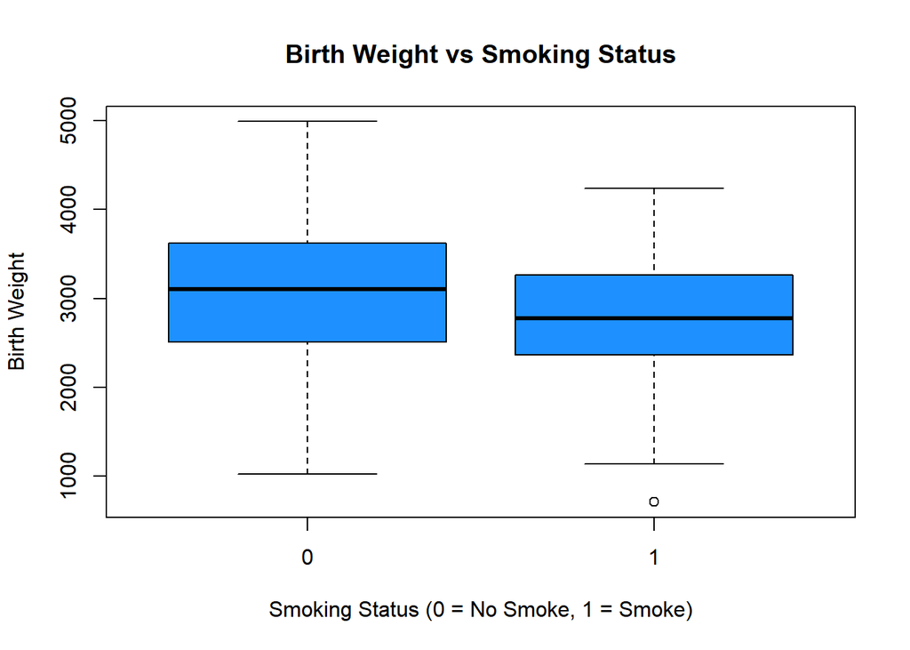

```r
boxplot(bwt ~ smoke, data = bw,
        xlab = "Smoking Status (0 = No Smoke, 1 = Smoke)",
        ylab = "Birth Weight",
        col = "dodgerblue",
        main = "Birth Weight vs Smoking Status")
```

Yes, the chart indicates smoking group have lower median birth weight.

## Exercise 3 (Importing Data, More Plotting)

For this exercise we will use the data stored in `nutrition-2018.csv`. It contains the nutritional values per serving size for a large variety of foods as calculated by the USDA in 2018. It is a cleaned version totaling 5956 observations and is current as of April 2018.

The variables in the dataset are:

- `ID`
- `Desc` - short description of food
- `Water` - in grams
- `Calories` - in kcal
- `Protein` - in grams
- `Fat` - in grams
- `Carbs` - carbohydrates, in grams
- `Fiber` - in grams
- `Sugar` - in grams
- `Calcium` - in milligrams
- `Potassium` - in milligrams
- `Sodium` - in milligrams
- `VitaminC` - vitamin C, in milligrams
- `Chol` - cholesterol, in milligrams
- `Portion` - description of standard serving size used in analysis

**(a)** Create a histogram of `Calories`. Do not modify `R`’s default bin selection. Make the plot presentable. Describe the shape of the histogram. Do you notice anything unusual?

```r
library(readr)
nu <- read_csv("nutrition-2018.csv")
```

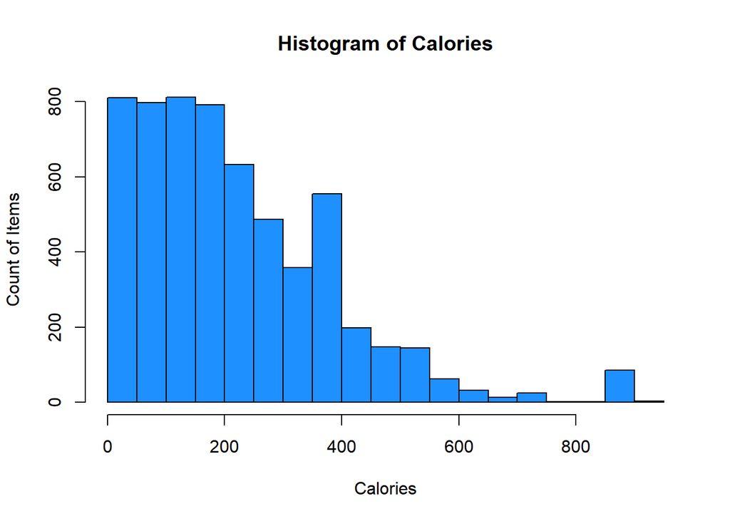

```r
hist(nu$Calories,
     main = "Histogram of Calories",
     xlab = "Calories",
     ylab = "Count of Items",
     col = "dodgerblue")
```

The histogram is roughly triangle-shaped with large number of items in low calories and reduce as the calories increase. The unusual thing is that there are relatively high number of items with high calorie (over 800) and exceeds the x axies.

**(b)** Create a scatter plot of calories (y-axis) vs protein (x-axis). Make the plot presentable. Do you notice any trends? Do you think that knowing only the protein content of a food, you could make a good prediction of the calories in the food?

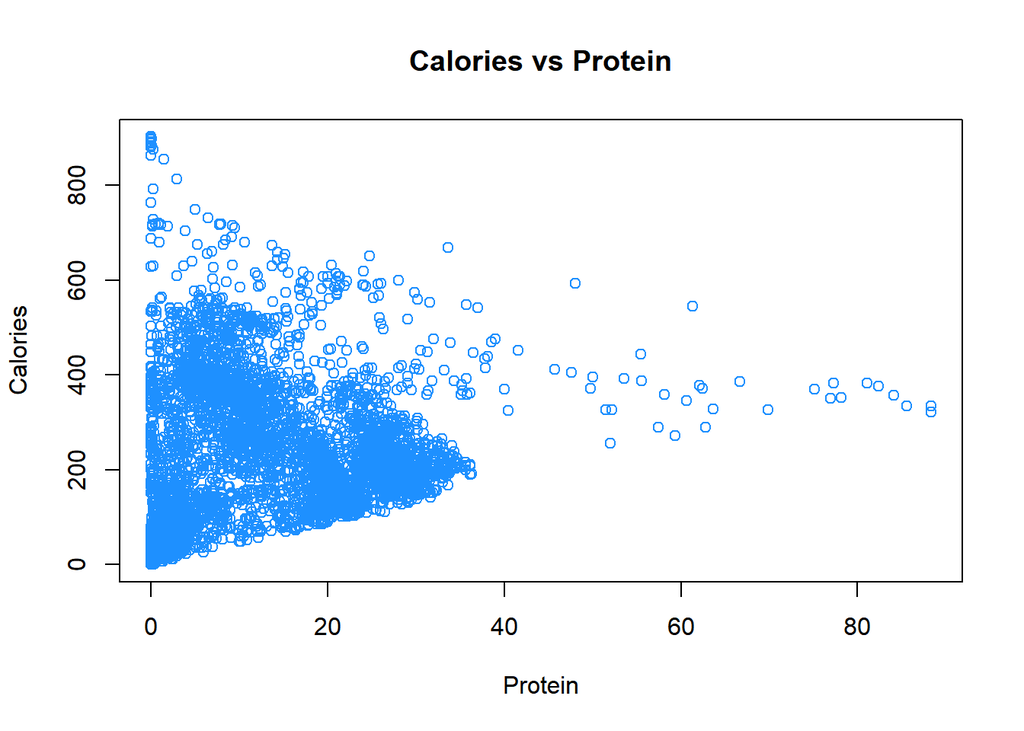

```r
plot(Calories ~ Protein, data = nu,
     main = "Calories vs Protein",
     xlab = "Protein",
     ylab = "Calories",
     col = "dodgerblue")
```

Trend: As protein increase, the minimum value of Calorie also increase. No. Only knowing the protein cannot predict the calories since low protein can have both low and high calories.

**(c)** Create a scatter plot of `Calories` (y-axis) vs `4 * Protein + 4 * Carbs + 9 * Fat` (x-axis). Make the plot presentable. You will either need to add a new variable to the data frame, or use the `I()` function in your formula in the call to `plot()`. If you are at all familiar with nutrition, you may realize that this formula calculates the calorie count based on the protein, carbohydrate, and fat values. You’d expect then that the result here is a straight line. Is it? If not, can you think of any reasons why it is not?

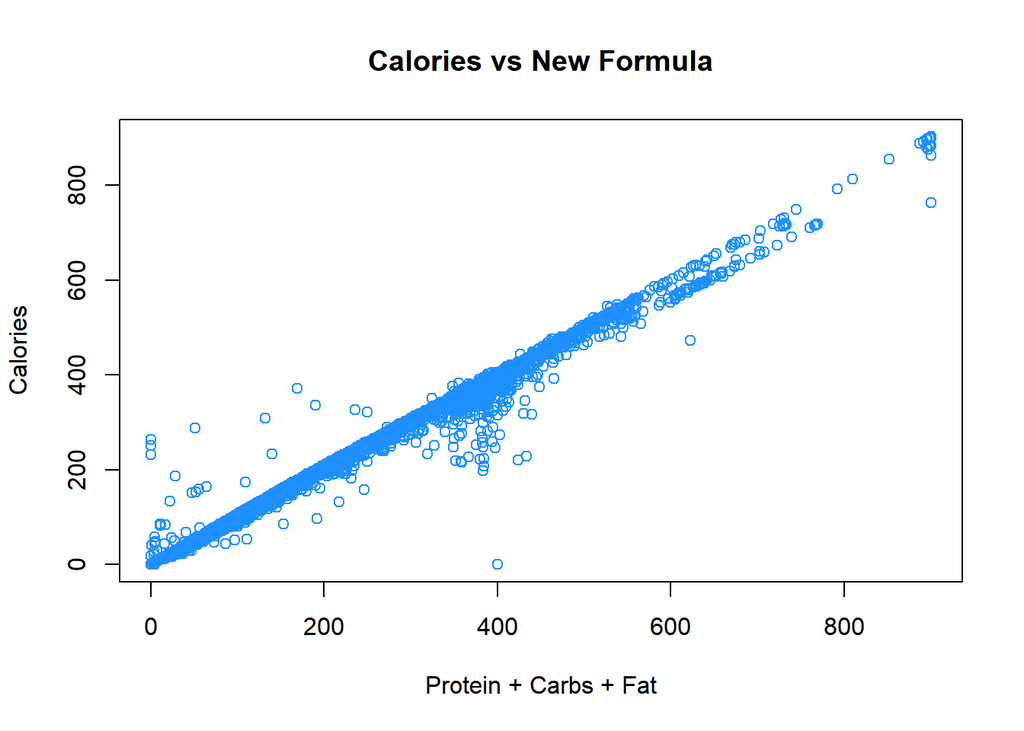

```r
pcf <- 4 * nu$Protein + 4 * nu$Carbs + 9 * nu$Fat
plot(Calories ~ pcf, data = nu, main = "Calories vs New Formula",
     xlab = "Protein + Carbs + Fat",
     ylab = "Calories",
     col = "dodgerblue")
```

No. Carb, Fat and Protein have various compounds and forms in molecular structure. Different types carry variable calories.

## Exercise 4 (Writing and Using Functions)

For each of the following parts, use the following vectors:

```r
a = 1:10
b = 10:1
c = rep(1, times = 10)
d = 2 ^ (1:10)
```

**(a)** Write a function called `sum_of_squares`.

- Arguments:
  - A vector of numeric data `x`
- Output:
  - The sum of the squares of the elements of the vector $\sum_{i = 1}^n x_i^2$

Provide your function, as well as the result of running the following code:

```r
sum_of_squares = function(x) {
  sum(x ^ 2)
}
```

```r
sum_of_squares(x = a)
sum_of_squares(x = c(c, d))
```

[output not shown]

**(b)** Using only your function `sum_of_squares()`, `mean()`, `sqrt()`, and basic math operations such as `+` and `-`, calculate

$$\sqrt{\frac{1}{n}\sum_{i = 1}^n (x_i - 0)^{2}}$$

where the $x$ vector is `d`.

```r
result <- sqrt(sum_of_squares(d - 0) / length(d))
result
```

```
## [1] 373.9118
```

**(c)** Using only your function `sum_of_squares()`, `mean()`, `sqrt()`, and basic math operations such as `+` and `-`, calculate

$$\sqrt{\frac{1}{n}\sum_{i = 1}^n (x_i - y_i)^{2}}$$

where the $x$ vector is `a` and the $y$ vector is `b`.

```r
res_c = sqrt(sum_of_squares(a - b) / length(a))
res_c
```

```
## [1] 5.744563
```

## Exercise 5 (More Writing and Using Functions)

For each of the following parts, use the following vectors:

```r
set.seed(42)
x = 1:100
y = rnorm(1000)
z = runif(150, min = 0, max = 1)
```

**(a)** Write a function called `list_extreme_values`.

- Arguments:
  - A vector of numeric data `x`
  - A positive constant, `k`, with a default value of `2`
- Output:
  - A list with two elements:
    - `small`, a vector of elements of `x` that are $k$ sample standard deviations less than the sample mean. That is, the observations that are smaller than $\bar{x} - k \cdot s$.
    - `large`, a vector of elements of `x` that are $k$ sample standard deviations greater than the sample mean. That is, the observations that are larger than $\bar{x} + k \cdot s$.

Provide your function, as well as the result of running the following code:

```r
list_extreme_values = function(x, k = 2) {
  x_bar <- mean(x)
  std <- sd(x)
  small <- x[x < (x_bar - k * std)]
  large <- x[x > (x_bar + k * std)]
  res <- list("small" = small, "large" = large)
  return(res)
}
```

```r
list_extreme_values(x = x, k = 1)
list_extreme_values(x = y, k = 3)
list_extreme_values(x = y, k = 2)
list_extreme_values(x = z, k = 1.5)
```

[output not shown]

**(b)** Using only your function `list_extreme_values()`, `mean()`, and basic list operations, calculate the mean of observations that are greater than 1.5 standard deviation above the mean in the vector `y`.

```r
mean(list_extreme_values(x = y, k=1.5)$large)
```

```
## [1] 1.970506
```